# How much uncertainty is too much?

Sam Petulla

4/23/2019

As a data visualization obsessive, I can’t help but read Nathan Yau’s [Flowing Data](https://flowingdata.com) and [Andy Kirk’s](http://visualisingdata.com) Visualising Data, two blogs that feature the best of visualization every day. While I know Yau has more of a statistical background and tends to put more emphasis on New York Times and Washington Post graphics, it is hard for me to say what else differentiates the two writers.

So I decided to build a classifer to do some of the work of figuring it out for me. To gather the blog posts, I used [my generic Node.js scraper](https://gist.github.com/petulla/40e88cf5dcf9cfdcbe253e281dfa925f) to compile CSV’s of almost ten years of blog posts from each writer.

First, we’ll do some exploratory analysis of the two writers to see what we find. Then we’ll fit a naive Bayes classifier and see if we can really tell a difference between the posters. Finally, we’ll try a fully naive Bayes classifer, with symmetric priors on each word.

```r
  needs('e1071')
  needs('tidyverse')
  needs('tm')
  needs('rstan')
  needs('bayesplot')
  needs('shinystan')
  needs('splitstackshape')
  needs('broom')

  # prevent tedious re-compilation during interactive Stan dev
  rstan_options(auto_write = TRUE)
  # use multiple cores during sampling
  options(mc.cores = parallel::detectCores())
  set.seed(123)
```

We’ll start by loading in our data and code the data.

```r
  yauRaw <- read.csv('1/yau.csv')
  kirkRaw <- read.csv('1/kirk.csv')
  # filter blank rows
  yauRaw <- yauRaw %>% filter(text != "") %>% mutate(author = 'yau')
  kirkRaw <- kirkRaw %>% filter(text != "") %>% mutate(author = 'kirk') %>% mutate(post = post + max(yauRaw$post, na.rm = TRUE))
  # stack
  vizPosts <- rbind(yauRaw, kirkRaw)
  # build authors DF
  Authors <- vizPosts %>% select(post, author) %>% group_by(post) %>% distinct(post, author);

  # group
  vizPosts <- tapply(vizPosts$text,         # data on separate lines
                    vizPosts$post,        # grouping variable
                    str_c, collapse=' ')    # function applied to group   (aka, "paste")

  # add authors
  vizPosts <- tibble(author=Authors$author, text=vizPosts)

  # randomly shuffle authors
  vizPosts <- slice(vizPosts, sample(1:n()))

  # save csv
  save(vizPosts, file="1/allPosts.sav")
```

```r
  # Randomly take 80% of the data for training
  randRows = sort(sample(0:nrow(vizPosts),80,replace=F))
  data.train <- vizPosts %>% mutate(author = ifelse(row_number() %in% randRows == TRUE, 'yau or kirk', author ))
```

We first tokenize our dataset and build a document matrix.

```r
  vizCorpus <- Corpus(VectorSource(data.train$text))

  #tokenize
  replace <- content_transformer(function(text, from, to) str_replace_all(text, from, to))
  toSpace <- content_transformer(function(text, pattern) str_replace_all(text, pattern, " "))
  toLower <- content_transformer(function(text) tolower(text))

  vizCorpus <- tm_map(vizCorpus, toLower)
  vizCorpus <- tm_map(vizCorpus, toSpace, '-|/|,|\\.')
  vizCorpus <- tm_map(vizCorpus, removePunctuation)
  vizCorpus <- tm_map(vizCorpus, removeNumbers)
  vizCorpus <- tm_map(vizCorpus, stripWhitespace)

  dtm <- DocumentTermMatrix(vizCorpus)

  ni <- rowSums(as.matrix(dtm))  # tokens in each document
  mj <- colSums(as.matrix(dtm))  # columns are named by the word types; frequency of each

  dtm.kirk <- dtm[data.train$author=='kirk',]
  dtm.yau <- dtm[data.train$author=='yau',]

  mj.kirk  <- colSums(as.matrix(dtm.kirk)) # type frequencies for each
  mj.yau <- colSums(as.matrix(dtm.yau))
```

We still have the stop words in our visualization, but a quick glance of the relative frequencies of words provides some insights into their authors: Kirk, who is English, writes more about The Guardian. Yau, the statistician, is more likely to mention the “average” or “statistics.” He also uses more contractions and seems to write more about color (or, maybe just doesn’t use the spelling colour?). This idea of relative frequency differences will be what our classifier is trained on.

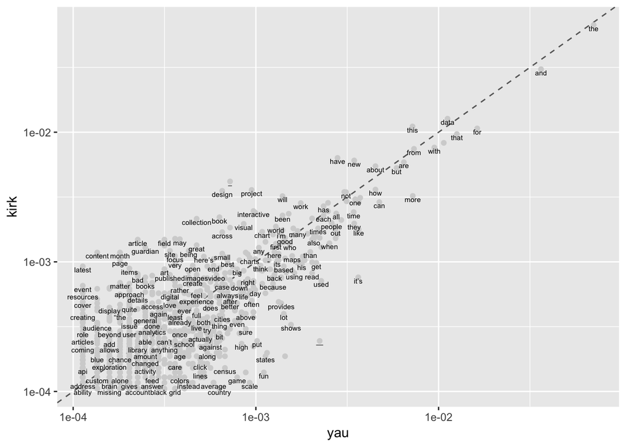

```r
  Counts <- bind_rows(                                 # dplyr style stacks these
              tibble(author="kirk",  word=names(mj.kirk),  count=mj.kirk),
              tibble(author="yau", word=names(mj.yau), count=mj.yau))

  Proportions <- Counts %>%
    group_by(author)                        %>%
    mutate(proportion = count / sum(count)) %>%
    select(-count)                          %>%   # messed up without this
    spread(key=author, value=proportion)

  Proportions %>%
    filter(0.0001 < yau & 0.0001 < kirk) %>%
    ggplot(aes(x=yau, y=kirk))  +
    geom_abline(color = "gray40", lty = 2) +
    geom_point(color='lightgray') +
    geom_text(aes(label = word), check_overlap=TRUE, vjust=1.15, size=2) +
    scale_y_log10() + scale_x_log10()
```

We’ll now train author our naive Bayes classifer. I won’t go too deep into naive Bayes – there are many good tutorials on YouTube and Medium – except to say that the general idea is that our sample text has a certain number of words used by each author.

We can therefore assign a probability that a word, $(W_j)$, is used in a text by each author Kirk or Yau.

Because we assume independence in the words (this is the naive part), predicting the author of a text sample from outside of our training set is then a matter of summing over all of the probabilities for each word in the text sample conditioned on each author. Our author prediction is the higher prediction $\prod_{i=1}^n P(w_i|author)$.

We’ll use helper function `good_turing_probabilities` to compute our word frequency probabilities.

```r
  prob.yau  <- good_turing_probabilities(mj.yau )
  prob.kirk <- good_turing_probabilities(mj.kirk)

  C <- as.matrix(dtm)

  lp.yau <- C %*% log(prob.yau)
  lp.kirk  <- C %*% log(prob.kirk)
  diff <- lp.yau - lp.kirk
```

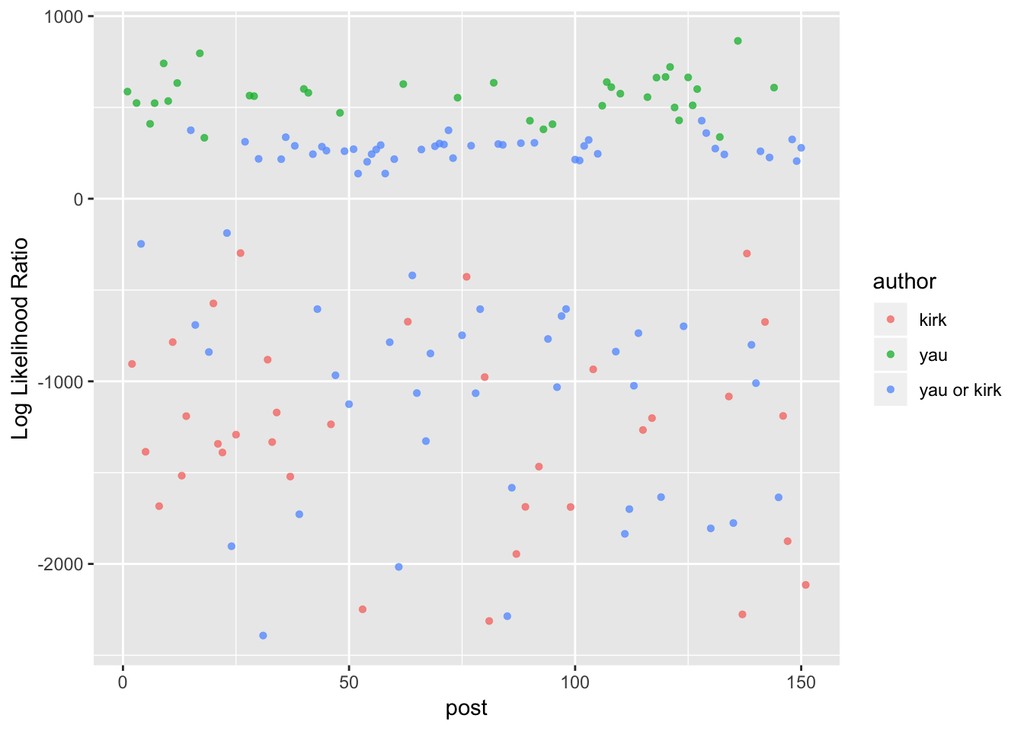

```r
  tibble(post=1:nrow(data.train), author=data.train$author, diff=as.vector(diff)) %>%
      ggplot(aes(post,diff,color=author)) +
      geom_point(alpha= 0.75, stroke=0.2) + labs(y="Log Likelihood Ratio")
```

Filtering down to just the test data and adding the labels back, we see our classifier performed with 100% success.

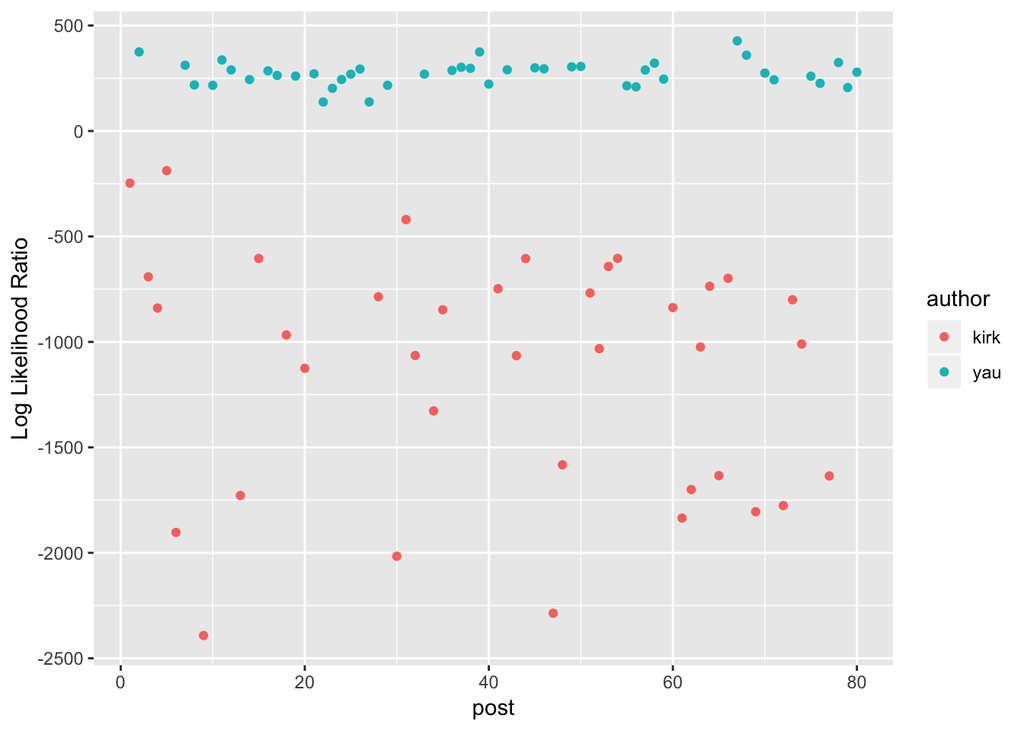

```r
  testResult <- tibble(post=1:nrow(data.train[randRows,]), author=vizPosts[randRows,]$author, diff=as.vector(diff[randRows,]))

  testResult %>%
      ggplot(aes(post,diff,color=author)) +
      geom_point() + labs(y="Log Likelihood Ratio")
```

```r
  # Error rate
  # 0% error rate, in spite of the challenging nature of the task
  nrow(testResult %>% filter(author == 'kirk' & diff > 0)) / nrow(testResult)
```

```
## [1] 0
```

Given that we’re dealing with probabilities, I wanted to see if I could go a step further and put priors on each word. The Stan manual has [an introduction](https://mc-stan.org/docs/2_19/stan-users-guide/naive-bayes-classification-and-clustering.html) to fully naive Bayesian inference and the multinomial structure of the model.

We’ll model each document as belonging to a category, $z_m$, (Kirk or Yau), modeled as parameter theta $\theta$.

$$z_m \sim \mathsf{Categorical}(\theta).$$
Each word, $w_{m,n}$, is modeled as a categorical distribution with parameter phi $\phi$ having a symmetric Dirichlet prior.

$$w_{m,n} \sim \mathsf{Categorical}(\phi_{z[m]}).$$
This adds some prior uncertainty to *every* word in the corpus and the prevelance of each author. We’ll now see how our model fits (Note: This took over 24 hours to run on my quad-core MBPr; I forgot to save a model with more iterations but the results analysis was close to the same.)

```r
  #melt, try to equalize the data sample size
  yauDF <- cSplit(yauRaw, "text", " ", "long") %>% select(-j) %>% filter(post <= 40)
  kirkDF <- cSplit(kirkRaw, "text", " ", "long") %>% select(-j) %>% filter(post <= min(kirkRaw$post) + 19)
  # merge authors
  alldf <- rbind(yauDF, kirkDF)
  #df with each word unique entry
  alldf$text <- as.character(alldf$text)
  # remove punctuation and lower the case
  alldf$text <- trimws(tolower(gsub('[[:punct:] ]+',' ', alldf$text)))
  # add column for unique word id to each row
  alldf$id <- match(alldf$text, unique(alldf$text) )

  nwords <- alldf %>%
    group_by(id) %>%
    summarise(count = n()) %>% filter(count > 25)

  alldf <- alldf %>% filter(id %in% nwords$id)
  alldf$id <- match(alldf$id, unique(alldf$id) )
```

As with before, we build train and test datasets. We will only test on 10 posts for demonstration.

```r
  #build train and test dataframes
  yauBreak <- min(yauDF$post) + floor((max(yauDF$post) - min(yauDF$post)) * 0.9)
  kirkBreak <- min(kirkDF$post) + floor((max(kirkDF$post) - min(kirkDF$post)) * 0.8)
  # train
  # reset the post ids to zero
  trainDiff <- min(kirkDF$post) - yauBreak
  alldfTrain <- alldf %>% filter(post < yauBreak| post > max(yauDF$post) & post < kirkBreak) %>% mutate(post = ifelse(post > max(yauDF$post), post - trainDiff, post))
  topicdfTrain <- alldfTrain %>% mutate(topic = ifelse(author == 'yau', 2, 1)) %>% select(c(post, topic)) %>% distinct(post, topic)
  # start the post ids from zero
  alldfTest <- alldf %>% filter(post >= yauBreak & post <= max(yauDF$post) | post >= kirkBreak)
  alldfTest$post <- match(alldfTest$post, unique(alldfTest$post))
  topicdfTest <- alldfTest %>% mutate(topic = ifelse(author == 'yau', 2, 1)) %>% select(c(post, topic)) %>% distinct(post, topic)
```

```r
  # topics (Yau and Kirk)
  K <- 2
  # unique words
  V <- max(alldfTrain$id)
  # documents (posts)
  M <- max(alldfTrain$post)
  # total words
  N <- nrow(alldfTrain)
  # priors
  alpha <- c(1L, 1L)
  beta <- rep(1/V, length.out = V)
  # topic for each doc (post)
  z <- topicdfTrain$topic
  # unique word id for each word
  w <- alldfTrain$id
  # unique doc id for each word
  doc <- alldfTrain$post

  N2 <- nrow(alldfTest)
  M2 <- max(alldfTest$post)
  w2 <- alldfTest$id
  doc2 <- alldfTest$post
```

```r
  m_path <- "./stan/naive.stan"
  m1 <- stan_model(m_path)
```

```r
  fit1 <- sampling(m1, chains=2, iter = 400, verbose = TRUE, save_warmup = FALSE, control = list(adapt_delta = 0.9))
  fit2 <- sampling(m1, chains=4, iter = 500, verbose = TRUE, save_warmup = FALSE, control = list(adapt_delta = 0.95))
```

```r
  fit1@stanmodel@dso <- new("cxxdso")
  fit2@stanmodel@dso <- new("cxxdso")
  saveRDS(fit1, file = "./1/fit1.rds")
  saveRDS(fit2, file = "./1/fit2.rds")
```

We see on gamma – our estimates for each post’s author – are not very good. We can see that the Markov chains did not mix particularly well, with rhat values bouncing around 1.

```r
  fit1 <- readRDS("./1/fit1.rds")
  fit2 <- readRDS("./1/fit2.rds")

  list_of_draws <- extract(fit2, permuted = FALSE)
  print(fit2, pars = "gamma", probs = c(0.025, 0.5, 0.975))
```

[output not shown]

```r
  gammaSummary <- summary(fit2, pars = "gamma", probs = c(0.025, 0.5, 0.975))$summary

  gammaVals <- as.data.frame(gammaSummary[, c("50%")]) %>% mutate(author = ifelse(row_number() %% 2 == 0, 2,1)) %>%
      mutate(test = ifelse(row_number() %% 2 == 0, row_number()/2, (row_number() + 1) / 2)) %>%
      mutate(val = gammaSummary[, c("50%")]) %>% select(-c('gammaSummary[, c("50%")]')) %>%
      group_by(test) %>%
        mutate(diff = diff(val)) %>%
          filter(test <= 5 & author == 1 | test > 5 & author == 2) %>% select(author, diff)

  diffMatches <- data.frame(diff %>% .[c(29L, 66L, 44L, 70L, 150L, 13L, 115L, 138L, 117L, 134L),])
  #diffMatches <- data.frame(diff %>% .[c(86L, 34L, 28L, 145L, 111L, 83L, 103L, 88L, 131L, 20L),])
  #diffMatches <- data.frame(diff %>% .[c(40L, 7L, 145L, 60L, 143L, 141L, 111L, 54L, 48L, 76L),])
  colnames(diffMatches) <- c("naive bayes estimate")
  rownames(diffMatches) <- 1:nrow(diffMatches)

  names(gammaVals)[3] <- c("fully bayesian naive bayes estimate")

  gammaVals <- cbind(diffMatches, as.data.frame(gammaVals))
  print(gammaVals)
```

```
##    naive bayes estimate test author fully bayesian naive bayes estimate
## 1              561.5537    1      1                            133.1498
## 2              269.4367    2      1                            136.9250
## 3              285.1618    3      1                            158.1607
## 4              302.1919    4      1                            199.8253
## 5              278.7444    5      1                            193.7320
## 6            -1516.5821    6      2                          -1994.6632
## 7            -1266.5146    7      2                           -695.2079
## 8             -300.1199    8      2                           -696.3224
## 9            -1201.4260    9      2                           -724.4402
## 10           -1083.0261   10      2                           -984.5822
```

Last, we spot check the chains, which we know are failing us. We see a lot of noise in the parameter estimate for theta $\theta$, our probability a text sample is from either author (note: the probabilities are so different because Yau’s posts are much shorter!)

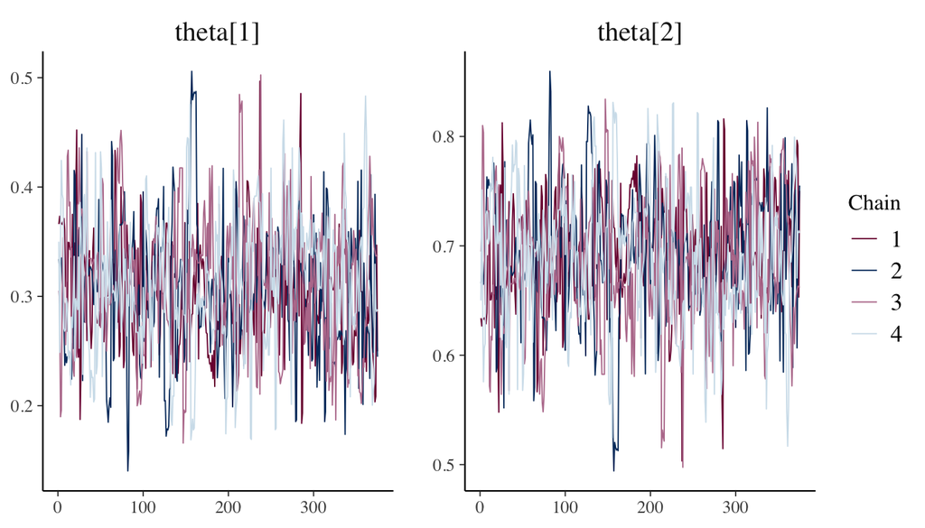

```r
  posterior2 <- extract(fit2, inc_warmup = TRUE, permuted = FALSE)

  color_scheme_set("mix-blue-pink")
  p <- mcmc_trace(posterior2,  regex_pars = "theta")
  p + facet_text(size = 15)
```

The Stan code.

```r
  data {
    // training data
    int<lower=1> K;               // num topics
    int<lower=1> V;               // num words
    int<lower=0> M;               // num docs
    int<lower=0> N;               // total word instances
    int<lower=1,upper=K> z[M];    // topic for doc m
    int<lower=1,upper=V> w[N];    // word n
    int<lower=1,upper=M> doc[N];  // doc ID for word n

    // unlabeled data
    int<lower=0> N2;               // total word instances
    int<lower=0> M2;               // num docs
    int<lower=1,upper=V> w2[N2];    // word n
    int<lower=1,upper=M2> doc2[N2];  // doc ID for word n

    // hyperparameters
    vector<lower=0,upper=1>[K] alpha;     // topic prior
    vector<lower=0,upper=1>[V] beta;      // word prior

  }
  parameters {
    //
    simplex[K] theta;   // topic prevalence
    simplex[V] phi[K];  // word dist for topic k
  }
  model {
    // priors
    // conjugate to categorical
    theta ~ dirichlet(alpha);
    for (k in 1:K) phi[k] ~ dirichlet(beta);

    // likelihood, including latent category
    z ~ categorical(theta);

    for (n in 1:N) w[n] ~ categorical(phi[z[doc[n]]]);
    // categorical distribution for each word.. with parameter phi having a symmetric Dirichlet prior.

  }
  generated quantities {
    real gamma[M2, K];
    real gammas[M2];
    for (m in 1:M2)
      for (k in 1:K)
        gamma[m, k] = categorical_lpmf(k | theta);
    for (n in 1:N2)
      for (k in 1:K)
        //
        gamma[doc2[n], k] += categorical_lpmf(w2[n] | phi[k]);

    //for (m in 1:M2)
     // gammas[m] = log_sum_exp(gamma[m]);
  }
```